# Tarea #4

**Jonnathan Alejandro Juárez Velásquez - 999007826** ## Reading .csv file

```r
setwd("~/MASTER/funadmetos de progrmacion/r-notebook/TAREAS/TAREA #4")
diamonds <- read.csv('diamonds.csv')
head(diamonds)
```

```
##   carat       cut color clarity depth table price    x    y    z
## 1  0.31     Ideal     G     VS1  62.4    55   802 4.35 4.33 2.71
## 2  1.50      Good     G     SI2  64.3    57  8190 7.29 7.20 4.66
## 3  0.90   Premium     H     VS2  62.8    58  3810 6.17 6.13 3.86
## 4  1.01     Ideal     F     VS2  60.9    58  7411 6.43 6.47 3.93
## 5  0.33 Very Good     D     VS1  63.2    56  1109 4.45 4.44 2.81
## 6  1.08     Ideal     G     VS1  62.0    55  6779 6.62 6.57 4.09
```

```r
library("dplyr")
```

```r
library(ggplot2)
```

## 1. Dispersión

### 1.1. Construya un gráfico de dispersión colocando en la estética carat (eje x) versus price (eje y), luego devuelva el gráfico.

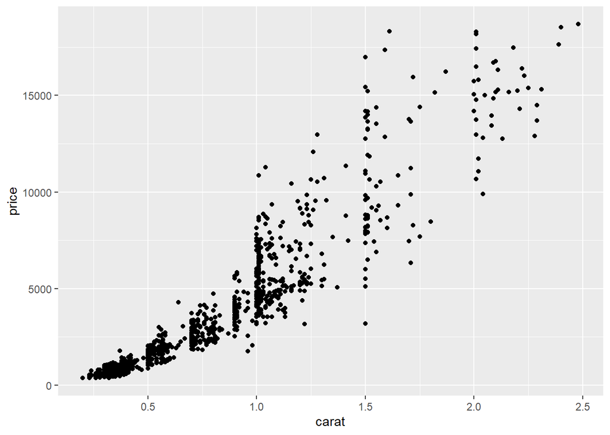

```r
ggplot(diamonds, aes(x=carat, y=price)) +
  geom_point()
```

### 1.2. Edite la estética y mapee el color con la variable clarity.

### 1.3. Devuelva el gráfico con esta modificación.

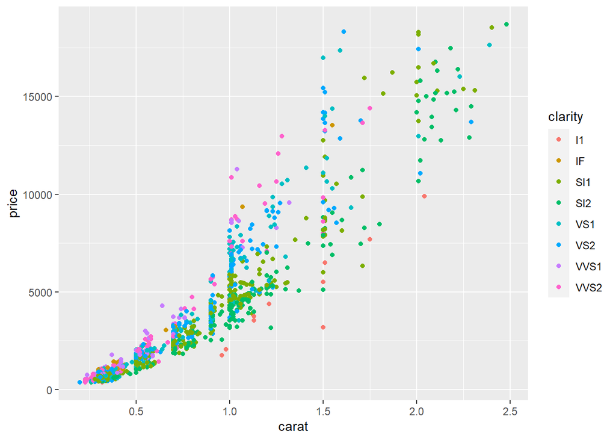

```r
ggplot(diamonds, aes(x=carat, y=price, color=clarity)) +
  geom_point()
```

## 2. Histograma

### 2.1. Construya el tipo de geometría histograma para la variable price. Configure el

parámetro bins con el valor 40 y devuelva el gráfico.

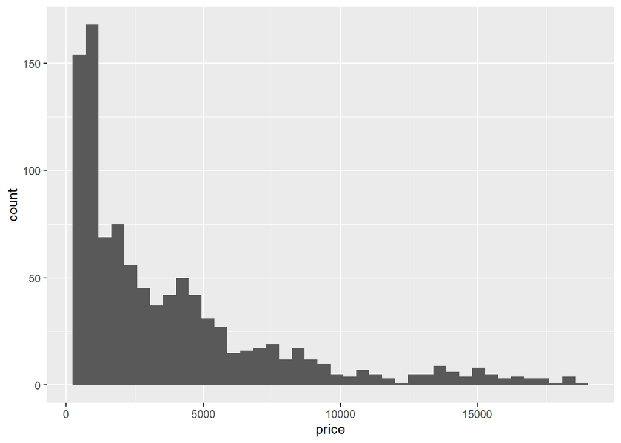

```r
ggplot(diamonds, aes(x=price)) +
  geom_histogram(bins = 40)
```

### 2.2. Agregue una escala logarítmica de base 10 y devuelva el gráfico para ver la

diferencia.

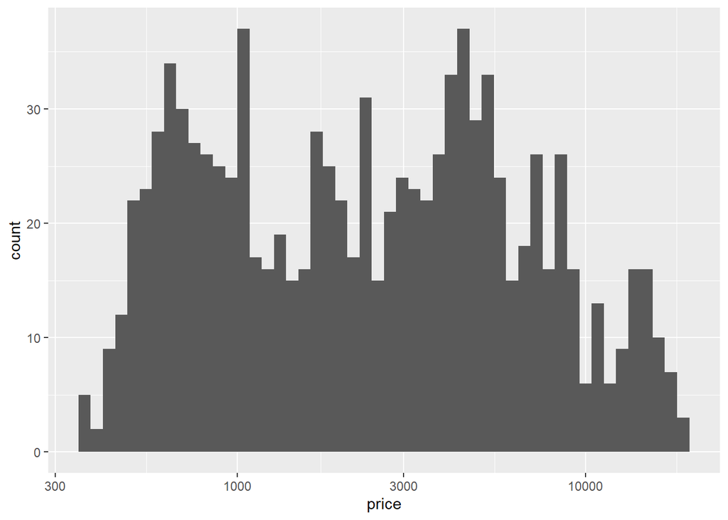

```r
ggplot(diamonds, aes(x=price)) +
  geom_histogram(bins=50) +
  scale_x_log10()
```

## 3. Boxplots

### 3.1. Construya un gráfico de cajas colocando en la estética la variable cut (eje x) versus price (eje y). Agregue una escala logarítmica por defecto y por último devuelva el gráfico.

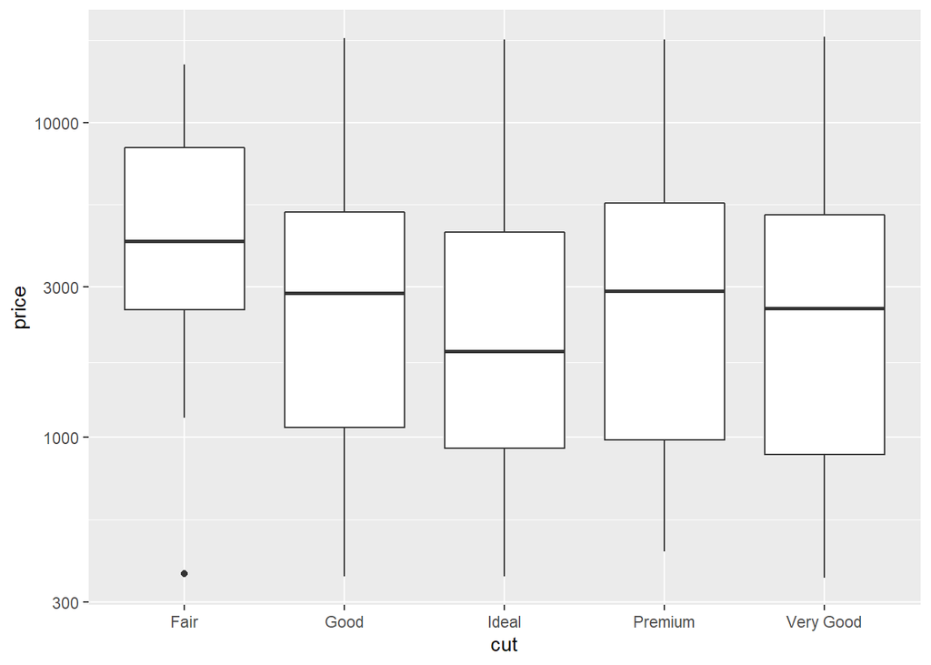

```r
ggplot(diamonds, aes(x=cut, y=price)) +
  geom_boxplot() +
  scale_y_log10()
```

### 3.2. Edite el color de cada caja con el parámetro fill dentro de la estética y asignando

la variable cut. Por último devuelva el gráfico.

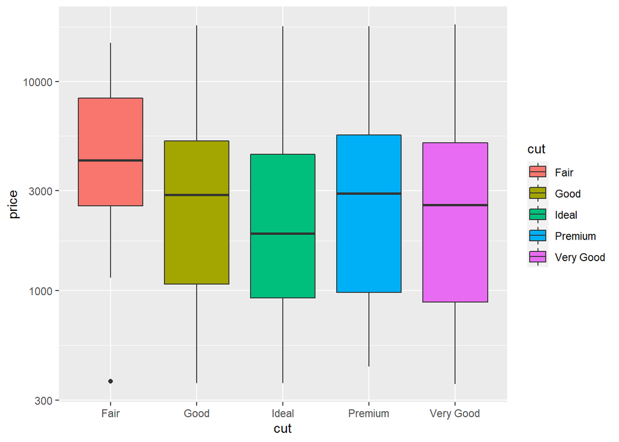

```r
ggplot(diamonds, aes(x=cut, y=price,fill=cut)) +
  geom_boxplot() +
  scale_y_log10()
```

## 4. Faceting ### 4.1. Filtre diamonds por la variable price que sea mayor a 1000 y por cut que contenga las categorías Good, Ideal y Premium. Luego asigne el resultado a la variable filtered_price. Dado que cut debe tomar en cuenta tres categorías específicas puede hacer uso del pipe %in%

```r
filtered_price <- diamonds %>%
filter (price > 1000 & cut %in% c("Good", "Ideal", "Premium") )

head(filtered_price)
```

```
##   carat     cut color clarity depth table price    x    y    z
## 1  1.50    Good     G     SI2  64.3    57  8190 7.29 7.20 4.66
## 2  0.90 Premium     H     VS2  62.8    58  3810 6.17 6.13 3.86
## 3  1.01   Ideal     F     VS2  60.9    58  7411 6.43 6.47 3.93
## 4  1.08   Ideal     G     VS1  62.0    55  6779 6.62 6.57 4.09
## 5  1.07 Premium     G     SI1  61.6    58  5453 6.60 6.56 4.05
## 6  0.44   Ideal     H      IF  62.0    57  1255 4.87 4.91 3.02
```

### 4.2. Utilice la variable filtered_price para construir un gráfico de barras, en la estética configure x = cut, y = depth.

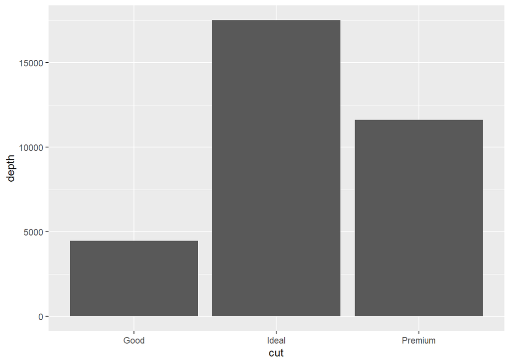

```r
ggplot(filtered_price, aes(x=cut, y=depth)) +
  geom_col()
```

### 4.3. Por último aplique faceting para la variable clarity y devuelva la parcela de gráficos.

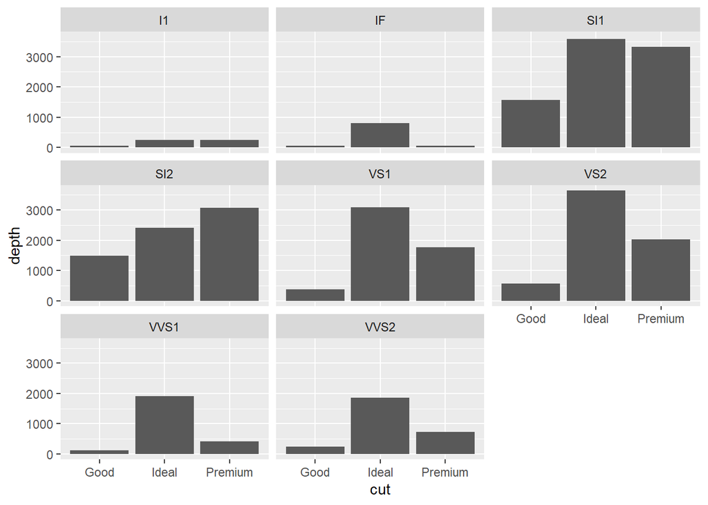

```r
ggplot(filtered_price, aes(x=cut, y=depth)) +
  geom_col()+
  facet_wrap(~ clarity)
```

### 4.4. Edite la estética y configure el parámetro fill con la variable clarity. Luego devuelva la parcela de gráficos con esta modificación.

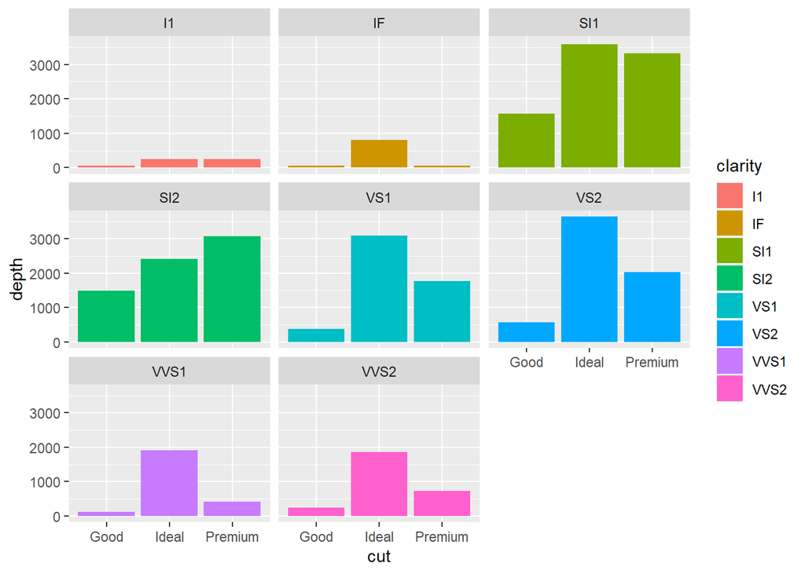

```r
ggplot(filtered_price, aes(x=cut, y=depth, fill=clarity)) +
  geom_col()+
  facet_wrap(~ clarity)
```